# Stephanie’s Housing Request

Week 2

## Background

Stephanie[^1] is a student that will be starting school at BYU-Idaho next semester. Suppose she sent you the following email.

“Hi. My name is Stephanie. I would like to learn about what housing options I have for living at BYU-Idaho next semester. It will be my first semester there, so I would like to find something that is close to campus and around $300 a month in rent. I’m not too picky on roommates, but I would like somewhere that has a lot of people around so I can get to know as many people as possible. Thanks in advance!”

Write your response to Stephanie below. Use the “Rent” dataset, good statistical analysis, and clear writing to make some well supported suggestions to her about apartments that meet her stated criterions. You are free to use other criterion that you think she might find more meaningful as well.

## Response

Dear Stephanie,

Here is a list of every apartment option in Rexburg. You would want to just focus on the second table that has been wrangled to fit what you are looking for in an apartment.

```r
# Code to get you started, be sure to use a subset of Rent instead of Rent in this code though.
datatable(Rent, options=list(lengthMenu = c(3,10,30)),
          extensions="Responsive",
          caption = 'Table 1: Base dataset')
```

|  | Apartment | Gender | Address | Phone | Price | PrivateRoomPrice | Capacity | ParkingStalls | Deposit | UtilityDeposit | FloorPlans | Website | Latitude | Longitude | MilesToCampus | WalkingMinutes | Description | MonthlyCost |
| --- | --- | --- | --- | --- | --- | --- | --- | --- | --- | --- | --- | --- | --- | --- | --- | --- | --- | --- |
| 1 | ABBY LANE MANOR | F | 437 S 4TH W | (208) 359-3687 | 1035 | 1060 | 42 | 38 | 100 | 0 | 3 | www.abbylaneapartments.com | 43.8169418 | -111.7952062 | 0.746 | 16 | We are a small women's complex offering private rooms and quaint living. Many students enjoy our advantages enough that they stay with us until graduation. We are sure you would like staying with us! … | 295.7 |
| 2 | ABODE DUPLEX | M | 224 E 2ND S | (912) 399-1107 | 980 | 980 | 6 | 3 | 100 | 0 | 1 | sites.google.com/site/robertspencerbrown/abodehouse | 43.8218153 | -111.7771495 | 0.186 | 4 | This cozy little apartment is located only one block from campus. There are a lot of freebies for the price. All utilities are included, there is a free-to-use, in-apartment washer and dryer, free WiF… | 280 |
| 3 | ABRI APARTMENTS - MEN | M | 220 E 1ST S | 2084177223 | 1420 | 1445 | 138 | 216 | 150 | 0 | 3 | www.liveabri.com | 43.8239342 | -111.7773062 | 0.311 | 8 | 24 hour special $100 off! Look no further than the Abri, Rexburg's newest student housing community. Currently leasing women's spots for fall '17, &amp; men's for winter '18. From upscale, modern fini… | 405.7 |
| 4 | ABRI APARTMENTS - WOMEN | F | 220 E 1ST S | (208) 417-7223 | 1445 | 1495 | 150 | 216 | 150 | 0 | 3 | www.liveabri.com | 43.8239342 | -111.7773062 | 0.311 | 8 | $100 OFF SPECIAL! Look no further than the Abri, Rexburg's newest student housing community. Currently leasing women's spots for fall '17, &amp; men's for winter '18. From upscale, modern finishes, to… | 412.9 |
| 5 | ALEXANDER APARTMENT | F | 276 W 3RD S | 208-995-8543 | 972 | 1115 | 22 | 18 | 100 | 0 | 10 | www.alexanderapartments.wordpress.com | 43.8197811 | -111.7918951 | 0.435 | 8 | We are also signing for Fall and Winter 2017. Get $25 off per semester for signing 2 consecutive semesters. No application fee or parking fee and get $40 in quarters for laundry each semester. | 277.7 |
| 6 | ALLEN RIDGE APARTMENTS | M | 57 S CENTER ST | (801) 864-1708 | 890 | 890 | 17 | 9 | 100 | 0 | 1 | allenridge.blogspot.com | 43.824663 | -111.7835934 | 0.311 | 6 | The best kept housing secret at BYU-Idaho. Small complex (only 17 tenants), but large living areas and rooms. Private, but in the best location in town - central to campus, shopping, and great activit… | 254.3 |
| 7 | ALLEN'S SUNRISE VILLAGE - MEN | M | 48 W 2ND S | 356-3995 | 1000 | 1075 | 138 | 133 | 100 | 0 | 3 | www.sunrisevillageapts.com | 43.821866 | -111.7852097 | 0.062 | 1 | Allen's Sunrise Village offers housing for both men and women! We are well-known for our friendliness,low prices,great location,fantastically reliable OPTIX internet,friendly residents and amazing man… | 285.7 |
| 8 | ALLEN'S SUNRISE VILLAGE - WOMEN | F | 48 W 2ND S | 208-356-3995 | 1000 | 1075 | 144 | 133 | 100 | 0 | 3 | www.sunrisevillageapts.com | 43.82186 | -111.785197 | 0.062 | 1 | We offer housing for both men and women! We are well-known for our friendliness, new modern remodel, low prices, great location, our fantastically reliable OPTIX internet and amazing managers. You'll … | 285.7 |
| 9 | ALPINE CHALET | M | 460 S 2ND W | (208) 356-9282 | 999 | 999 | 252 | 111 | 75 | 0 | 1 | www.rexburghousing.com | 43.8165761 | -111.7895659 | 0.435 | 10 | Alpine Chalet is a great place to live! It is close to campus and surrounded by many BYUI housing complexes. It has an amazing pool, hot tub, and weight room. Not to mention, we added 2nd fridges and … | 285.4 |
| 10 | ALTA VIEW APARTMENTS | M | 346 W 2ND S | 208-360-0097 | 895 | 895 | 26 | 30 | 80 | 0 | 19 | www.altaviewapts.com | 43.8218751 | -111.7938578 | 0.373 | 7 | Make Alta View your home next semester. Alta View Apartments is BYUI mens approved housing. Newly remodeled, comfortable, affordable housing. Free satellite television, Optix high-speed internet, grea… | 255.7 |

[output cut: 97 more lines]

```r
Stephanie <- female_rent %>%
  select(- Gender, - PrivateRoomPrice, - Price) %>%
  filter(Capacity > 100, MonthlyCost <= 350) %>%
  select(- UtilityDeposit, - Address, - Phone, - FloorPlans, - Website, - Description, - ParkingStalls, - Latitude, - Longitude, - Deposit, - WalkingMinutes) %>%
  arrange(MilesToCampus, MonthlyCost, Capacity)

pander(Stephanie, caption = "Table 2: Stephanie's Question")
```

Table 2: Stephanie’s Question

| Apartment | Capacity | MilesToCampus | MonthlyCost |
| --- | --- | --- | --- |
| BIRCH PLAZA | 343 | 0.062 | 280 |
| ALLEN’S SUNRISE VILLAGE - WOMEN | 144 | 0.062 | 285.7 |
| CARRIAGE HOUSE | 234 | 0.062 | 307.1 |
| KENSINGTON MANOR - WOMEN | 108 | 0.062 | 349.7 |
| ROYAL CREST | 342 | 0.186 | 284.3 |
| LA JOLLA - WOMEN | 234 | 0.186 | 322.6 |
| HILLCREST TOWNHOUSES | 140 | 0.249 | 321.4 |
| BROOKLYN APARTMENTS | 144 | 0.373 | 248.6 |
| ASPEN VILLAGE - WOMEN | 210 | 0.373 | 257.1 |
| AMERICAN AVENUE - WOMEN | 165 | 0.373 | 300 |
| SOMERSET APARTMENTS - WOMEN | 180 | 0.373 | 317.1 |
| ROOST, THE - WOMEN | 114 | 0.497 | 335.7 |

The Apartment I would recommend given the data from the table above is Birch Plaza. It fits all you are looking for in an apartment. Birch Plaza has a capacity of 343 which allows you to meet new people. It is .062 miles from campus making it one of the closest apartments to campus. The monthly cost is 280 dollars which is a pretty cheap monthly cost compared to other apartments in Rexburg.

Below is a picture of Birch Plaza. You can literally see the BYUI Stadium from the parking lot. So it’s literally across the street from campus.

[figure not shown]

This visualization show Birch Plaza as a circle and other apartments as triangles. This graph helps show apartments with respect to distance and cost. We can see that visually Birch Plaza is the best compared to other apartments. In the graph you can see the point for birch plaza on buttom left of the plot. That point shows its the cheapest based on similar distance from campus.

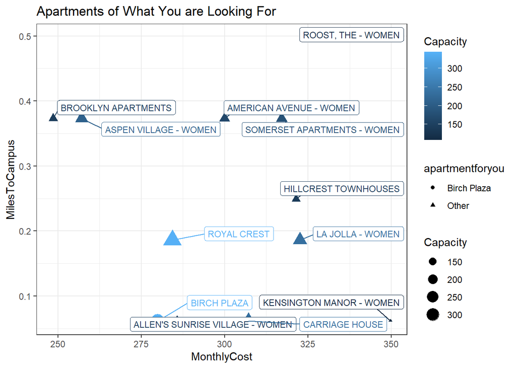

```r
Stephanie %>%
  mutate(apartmentforyou = ifelse(Apartment == "BIRCH PLAZA", "Birch Plaza", "Other")) %>%
  ggplot(aes(x = MonthlyCost, y = MilesToCampus, color = Capacity, shape = apartmentforyou, label = Apartment)) +
  geom_point(aes(size = Capacity)) +
  geom_label_repel(force = 3, size = 3, nudge_x = 20, nudge_y = .01, min.segment.length = 0) +
  #scale_size_manual(values = c(6, 3)) +
  theme_bw() +
  labs(title="Apartments of What You are Looking For")
```

I hope this helps.

Kyle Tolliver

[^1]: Note that Stephanie is a fictional character who is based on real experiences of many faculty and staff here at BYU-Idaho.